# Project: No-show appointments EDA

- Introduction
- Data Wrangling
- Exploratory Data Analysis
- Conclusions

## Introduction

> This report will analyze the dataset of No-show appointments(original download from Kaggle).This dateset collects information from 100k medical appointments in Brazil and is focused on the question of whether or not patients show up for their appointment. A number of characteristics about the patient are included in each row.

> This report will analyze what factors are important to know in order to predict if a patient will show up for their scheduled appointment?

> More specific, this article will analyze following questions:
> - Does Gender affect whether people show up for the appointment?
> - Does Scholarship affect whether people show up for the appointment?
> - Does Disease type affect whether people show up for the appointment?
> - Does Neighbourhood affect whether people show up for the appointment?
> - Does Age affect whether people show up for the appointment?

```python
# import important packages
import pandas as pd
import numpy as np
import matplotlib.pyplot as plt
import datetime as dt
import seaborn as sns
```

## Data Wrangling

### 1.General Properties

```python
#load data and display the head
data = pd.read_csv('noshowappointments-kagglev2-may-2016.csv')
display(data.head())
```

|  | PatientId | AppointmentID | Gender | ScheduledDay | AppointmentDay | Age | Neighbourhood | Scholarship | Hipertension | Diabetes | Alcoholism | Handcap | SMS_received | No-show |
| --- | --- | --- | --- | --- | --- | --- | --- | --- | --- | --- | --- | --- | --- | --- |
| 0 | 2.987250e+13 | 5642903 | F | 2016-04-29T18:38:08Z | 2016-04-29T00:00:00Z | 62 | JARDIM DA PENHA | 0 | 1 | 0 | 0 | 0 | 0 | No |
| 1 | 5.589978e+14 | 5642503 | M | 2016-04-29T16:08:27Z | 2016-04-29T00:00:00Z | 56 | JARDIM DA PENHA | 0 | 0 | 0 | 0 | 0 | 0 | No |
| 2 | 4.262962e+12 | 5642549 | F | 2016-04-29T16:19:04Z | 2016-04-29T00:00:00Z | 62 | MATA DA PRAIA | 0 | 0 | 0 | 0 | 0 | 0 | No |
| 3 | 8.679512e+11 | 5642828 | F | 2016-04-29T17:29:31Z | 2016-04-29T00:00:00Z | 8 | PONTAL DE CAMBURI | 0 | 0 | 0 | 0 | 0 | 0 | No |
| 4 | 8.841186e+12 | 5642494 | F | 2016-04-29T16:07:23Z | 2016-04-29T00:00:00Z | 56 | JARDIM DA PENHA | 0 | 1 | 1 | 0 | 0 | 0 | No |

```python
#check missing data
data.isna().sum()
```

```
PatientId         0
AppointmentID     0
Gender            0
ScheduledDay      0
AppointmentDay    0
Age               0
Neighbourhood     0
Scholarship       0
Hipertension      0
Diabetes          0
Alcoholism        0
Handcap           0
SMS_received      0
No-show           0
dtype: int64
```

```python
#check the type of each column
data.dtypes
```

```
PatientId         float64
AppointmentID       int64
Gender             object
ScheduledDay       object
AppointmentDay     object
Age                 int64
Neighbourhood      object
Scholarship         int64
Hipertension        int64
Diabetes            int64
Alcoholism          int64
Handcap             int64
SMS_received        int64
No-show            object
dtype: object
```

```python
#check the repeated patient
print(data['PatientId'].nunique())
print(data['AppointmentID'].nunique())
```

```
62299
110527
```

> There are 62299 patients who make 110527 appointments in total.

### 2.Data Cleaning - drop duplication

```python
#check the shape of original data
print(data.shape)
#drop the duplicates and check the shape again
data.drop_duplicates
print(data.shape)
```

```
(110527, 14)
(110527, 14)
```

> There is no duplicated row in the dataset.

### 3.Data Cleaning - Convert type of columns

```python
#datetime
data['ScheduledDay'] = pd.to_datetime(data['ScheduledDay'])
data['AppointmentDay'] = pd.to_datetime(data['AppointmentDay'])
#remove the timezone
data['ScheduledDay'] = data['ScheduledDay'].dt.tz_localize(None)
data['AppointmentDay'] = data['AppointmentDay'].dt.tz_localize(None)
#gender
data['Gender'].astype('category')
data['No-show'].astype('category')
```

```
0         No
1         No
2         No
3         No
4         No
          ..
110522    No
110523    No
110524    No
110525    No
110526    No
Name: No-show, Length: 110527, dtype: category
Categories (2, object): [No, Yes]
```

### 4.Data Cleaning - 'Age'

```python
display(data['Age'].describe())
```

```
count    110527.000000
mean         37.088874
std          23.110205
min          -1.000000
25%          18.000000
50%          37.000000
75%          55.000000
max         115.000000
Name: Age, dtype: float64
```

> We could see that the lowest age is -1,which does not make sense.

```python
#drop the rows where age <= 0
data = data[data['Age'] > 0]
#categorize the 'Age' into ['children','adult','old'] for further analysis
def age_cat(row):
    if row <= 18:
        return 'children'
    if (row <=50) & (row>18):
        return 'adult'
    else:
        return 'old'
data['Age_cat'] = data['Age'].apply(age_cat)
display(data.head(5))
```

|  | PatientId | AppointmentID | Gender | ScheduledDay | AppointmentDay | Age | Neighbourhood | Scholarship | Hipertension | Diabetes | Alcoholism | Handcap | SMS_received | No-show | Age_cat |
| --- | --- | --- | --- | --- | --- | --- | --- | --- | --- | --- | --- | --- | --- | --- | --- |
| 0 | 2.987250e+13 | 5642903 | F | 2016-04-29 18:38:08 | 2016-04-29 | 62 | JARDIM DA PENHA | 0 | 1 | 0 | 0 | 0 | 0 | No | old |
| 1 | 5.589978e+14 | 5642503 | M | 2016-04-29 16:08:27 | 2016-04-29 | 56 | JARDIM DA PENHA | 0 | 0 | 0 | 0 | 0 | 0 | No | old |
| 2 | 4.262962e+12 | 5642549 | F | 2016-04-29 16:19:04 | 2016-04-29 | 62 | MATA DA PRAIA | 0 | 0 | 0 | 0 | 0 | 0 | No | old |
| 3 | 8.679512e+11 | 5642828 | F | 2016-04-29 17:29:31 | 2016-04-29 | 8 | PONTAL DE CAMBURI | 0 | 0 | 0 | 0 | 0 | 0 | No | children |
| 4 | 8.841186e+12 | 5642494 | F | 2016-04-29 16:07:23 | 2016-04-29 | 56 | JARDIM DA PENHA | 0 | 1 | 1 | 0 | 0 | 0 | No | old |

> We categorize the 'Age' into three categories: Children, adult and old for further analysis.

## Exploratory Data Analysis

### 1.Does Gender affect whether people show up for the appointment?

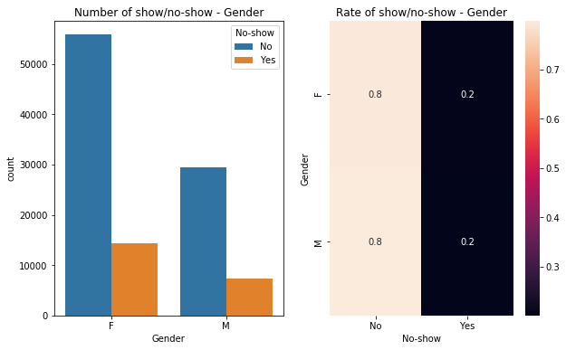

```python
#set figure size
plt.figure(figsize = (10,6))
#coutplot of Gender
plt.subplot(121)
sns.countplot(x = 'Gender',data = data,hue = 'No-show')
plt.title('Number of show/no-show - Gender')
#heatmap of Gender to show the proportion
plt.subplot(122)
sns.heatmap(pd.crosstab(data['Gender'], data['No-show'],normalize='index'),annot=True)
plt.title('Rate of show/no-show - Gender')
```

> From the countplot and heatmap of 'Gender' variable, we could see that the portions of people who show up for the appointment are both 80% in Male and Female group.  
> This shows 'Gender' might not be the factor influence whether people show up for the appointment.

### 2.Does Scholarship affect whether people show up for the appointment?

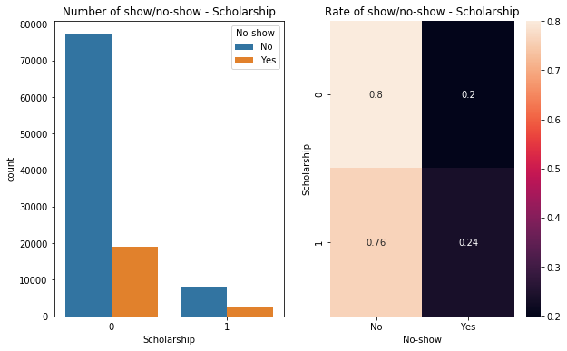

```python
plt.figure(figsize = (10,6))
#coutplot of Scholarship
plt.subplot(121)
sns.countplot(x = 'Scholarship',data = data,hue = 'No-show')
plt.title('Number of show/no-show - Scholarship')
#heatmap of Scholarship to show the proportion
plt.subplot(122)
sns.heatmap(pd.crosstab(data['Scholarship'], data['No-show'],normalize = 'index'),annot=True)
plt.title('Rate of show/no-show - Scholarship')
```

> From the countplot and heatmap of 'Scholarship' variable, we could see that people who is enrolled in Brasilian welfare program has higher rate of not-show(24%) in the appointment.  
> This shows 'Scholarship' is the factor that influence whether people show up for the appointment.

### 3.Does Disease type affect whether people show up for the appointment?

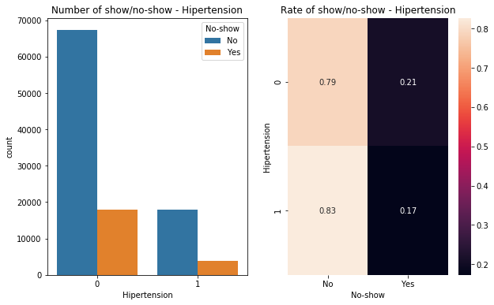

```python
#plot of Hipertension
plt.figure(figsize = (10,6))
#coutplot of Hipertension
plt.subplot(121)
sns.countplot(x = 'Hipertension',data = data,hue = 'No-show')
plt.title('Number of show/no-show - Hipertension')
#heatmap of Hipertension to show the proportion
plt.subplot(122)
sns.heatmap(pd.crosstab(data['Hipertension'], data['No-show'],normalize='index'),annot=True)
plt.title('Rate of show/no-show - Hipertension')
```

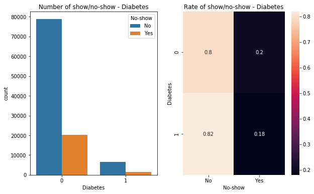

```python
#plot of Diabetes
plt.figure(figsize = (10,6))
#coutplot of Diabetes
plt.subplot(121)
sns.countplot(x = 'Diabetes',data = data,hue = 'No-show')
plt.title('Number of show/no-show - Diabetes')
#heatmap of Diabetes to show the proportion
plt.subplot(122)
sns.heatmap(pd.crosstab(data['Diabetes'], data['No-show'],normalize='index'),annot=True)
plt.title('Rate of show/no-show - Diabetes')
```

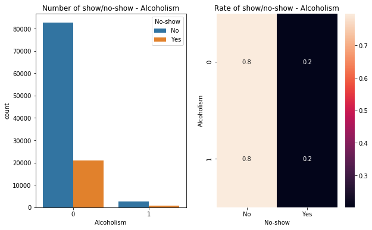

```python
#plot of Diabetes
plt.figure(figsize = (10,6))
#coutplot of Alcoholism
plt.subplot(121)
sns.countplot(x = 'Alcoholism',data = data,hue = 'No-show')
plt.title('Number of show/no-show - Alcoholism')
#heatmap of Alcoholism to show the proportion
plt.subplot(122)
sns.heatmap(pd.crosstab(data['Alcoholism'], data['No-show'],normalize='index'),annot=True)
plt.title('Rate of show/no-show - Alcoholism')
```

> From the above graphs, we could see that disease type could a factor influence whether a patient show up or not in one appointment.  
> To be more specific, patient who got Hipertension or Diabetes has lower rate of no-show for the appointment.

### 4.Does Neighbourhood affect whether people show up for the appointment?

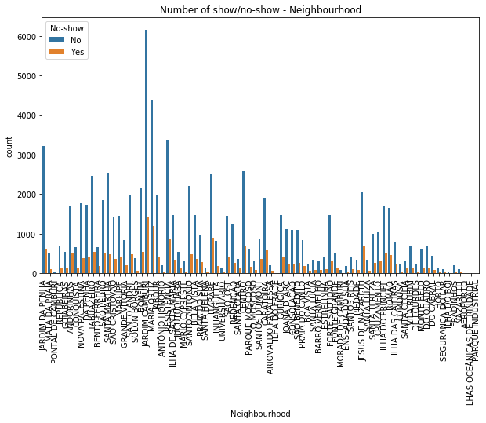

```python
#coutplot of neighbourhood
plt.figure(figsize=(10,6))
sns.countplot(x = 'Neighbourhood',data = data,hue = 'No-show')
plt.xticks(rotation = 90)
plt.title('Number of show/no-show - Neighbourhood')
```

```python
#plot the top 5 Neighbourhoods who has the highest proportion to show in the appointment
#convert the 'No-show'column from Yes/No to 0-1 for easier calculation
data['No-show'] = data['No-show'].replace({'Yes': 1, 'No': 0})
#create 'no-show/total appointmen'column
group = data.groupby(['Neighbourhood']).agg({'AppointmentID':'count','No-show':'sum'}).reset_index()
group['no-show/total appointment'] = group['No-show'] / group['AppointmentID']
#sort and show 5 neighbourhood with lowest appointment rate
group_least5 = group.sort_values('no-show/total appointment')[0:5]
display(group_least5)
#sort and show 5 neighbourhood with highest appointment rate
group_highest5 = group.sort_values('no-show/total appointment',ascending = False)[0:5]
display(group_highest5)
```

|  | Neighbourhood | AppointmentID | No-show | no-show/total appointment |
| --- | --- | --- | --- | --- |
| 51 | PARQUE INDUSTRIAL | 1 | 0 | 0.000000 |
| 31 | ILHA DO BOI | 35 | 3 | 0.085714 |
| 0 | AEROPORTO | 8 | 1 | 0.125000 |
| 48 | MÁRIO CYPRESTE | 367 | 53 | 0.144414 |
| 73 | SOLON BORGES | 452 | 67 | 0.148230 |

|  | Neighbourhood | AppointmentID | No-show | no-show/total appointment |
| --- | --- | --- | --- | --- |
| 34 | ILHAS OCEÂNICAS DE TRINDADE | 2 | 2 | 1.000000 |
| 70 | SANTOS DUMONT | 1249 | 364 | 0.291433 |
| 61 | SANTA CECÍLIA | 443 | 120 | 0.270880 |
| 62 | SANTA CLARA | 496 | 132 | 0.266129 |
| 36 | ITARARÉ | 3412 | 898 | 0.263189 |

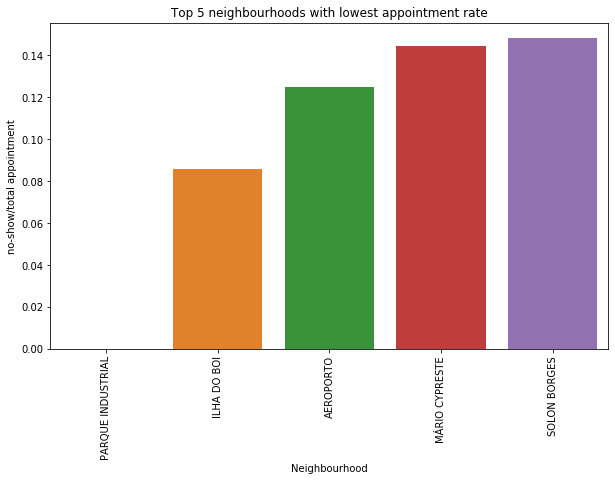

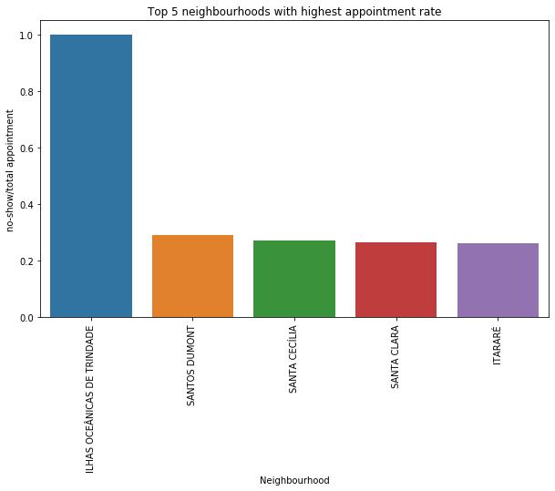

```python
#plot the top 5 neighbourhood with lowest appointment rate
plt.figure(figsize = (10,6))
sns.barplot(x = 'Neighbourhood',y = 'no-show/total appointment',data = group_least5)
plt.xticks(rotation = 90)
plt.title('Top 5 neighbourhoods with lowest appointment rate')
plt.show()
#plot the top 5 neighbourhood with lowest appointment rate
plt.figure(figsize = (10,6))
sns.barplot(x = 'Neighbourhood',y = 'no-show/total appointment',data = group_highest5)
plt.xticks(rotation = 90)
plt.title('Top 5 neighbourhoods with highest appointment rate')
plt.show()
```

> From the above graphs, we could see that different neighbourhoods has different show-up rate, and we display the top 5 neighbourhoods with highest rate and top 5 neighbourhoods with lowest rate.

### 5.Does Age affect whether people show up for the appointment?

```
<function matplotlib.pyplot.show(*args, **kw)>
```

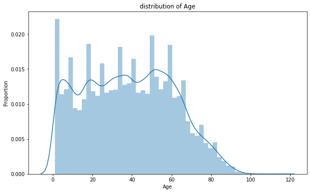

```python
#plot histogram of Age with kde
plt.figure(figsize = (10,6))
sns.distplot(data['Age'])
plt.title('distribution of Age')
plt.ylabel('Proportion')
plt.show
```

> From the histogram of age, we could see that the number of baby (whose age is under 3 years old) patient counts for over 4% of the total group;  
> Meanwhile, the graph shows that the number of patient whose age exceeds 60 years old drops sharply.

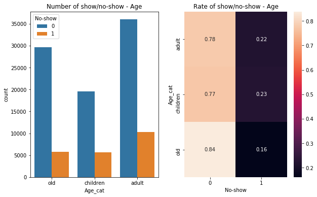

```python
#plot countplot and heatmap of 'Age' variable
plt.figure(figsize = (10,6))
plt.subplot(121)
sns.countplot(x = 'Age_cat',hue = 'No-show',data = data)
plt.title('Number of show/no-show - Age')
plt.subplot(122)
sns.heatmap(pd.crosstab(data['Age_cat'],data['No-show'],normalize = 'index'),annot = True)
plt.title('Rate of show/no-show - Age')
```

> We could see that people who age > 50 has the highest show-up rate for the appointment compared to other two groups. This shows age could be an important factor to predict people's bahavior.

## Conclusions

> To summerize, 'Scholarship', 'Disease type', 'Neighbourhood' and 'Age' are the important factors to know in order to predict whether the patient will show up in the appointment. To be more specific:
> - 'Gender' might not be the factor influence whether people show up for the appointment since groups in different gender have same rate of not-show in the appointment;
> - When it comes to 'Scholarship', people who is enrolled in Brasilian welfare program has higher rate of not-show(24%) in the appointment than the other group;
> - Condidering disease type, patient who got Hipertension or Diabetes has lower rate of no-show for the appointment. However, Alcoholism might not influence patient's decision to show-up in an appointment;
> - Different neighbourhoods has different show-up rate;
> - Age could be the factor influence people's behavior, and people who age > 50 has the highest show-up rate for the appointment compared to other two groups.